# CRABS AGE PREDICTION

```python
import pandas as pd
import numpy as np
import matplotlib.pyplot as plt
import seaborn as sns
import warnings
warnings.filterwarnings('ignore')
from scipy.stats import zscore
```

## CRAB'S AGE PREDICTION

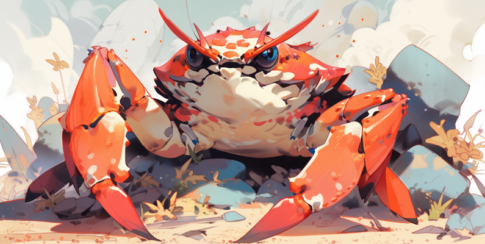

## Overview

### Crab farming is a major aquaculture activity as there is a huge consumption demand of crabs in India. Commercial crab farming is a growing business in coastal areas of India and is looking profitable. Mud crab is highly popular due to its great demand in the export market. The commercial scale mud crab culture is developing fast along the coastal areas of Andhra Pradesh, Tamil Nadu, Kerala and Karnataka.

### Larger Species: The larger species is locally known as `green mud crab’. It grows to a maximum size of 22 cm carapace width and 2 kg in weight.

### Smaller Species: The smaller species is known as `red claw’. This grows to a maximum size of 12.7 cm carapace width and 1.2 kg in weight.

### For more about Mud crab farming, please visit this link. To understand more on Mud crab, visit this link.

## Business Problem

### For a commercial crab farmer knowing the right age of the crab helps them decide if and when to harvest the crabs. Beyond a certain age, there is negligible growth in crab’s physical characteristics and hence, it is important to time the harvesting to reduce cost and increase profit.

```python
df=pd.read_csv('crab.csv')
df
```

|  | id | Sex | Length | Diameter | Height | Weight | Shucked Weight | Viscera Weight | Shell Weight | Age |
| --- | --- | --- | --- | --- | --- | --- | --- | --- | --- | --- |
| 0 | 0 | M | 1.5750 | 1.2250 | 0.3750 | 31.226974 | 12.303683 | 6.321938 | 9.638830 | 10.0 |
| 1 | 1 | I | 1.2375 | 1.0000 | 0.3750 | 21.885814 | 7.654365 | 3.798833 | 7.654365 | 19.0 |
| 2 | 2 | F | 1.4500 | 1.1625 | 0.4125 | 28.250277 | 11.127179 | 7.016501 | 7.257472 | 11.0 |
| 3 | 3 | I | 1.3500 | 1.0250 | 0.3750 | 21.588144 | 9.738053 | 4.110678 | 6.378637 | 9.0 |
| 4 | 4 | I | 1.1375 | 0.8750 | 0.2875 | 14.968536 | 5.953395 | 2.962523 | 3.713785 | 8.0 |
| ... | ... | ... | ... | ... | ... | ... | ... | ... | ... | ... |
| 199995 | 199995 | F | 1.8125 | 1.2750 | 0.4375 | 42.141532 | 20.000572 | 9.979024 | 11.609120 | 11.0 |
| 199996 | 199996 | F | 0.9875 | 0.6750 | 0.2375 | 7.980384 | 3.742134 | 1.913591 | 2.267960 | 6.0 |
| 199997 | 199997 | M | 1.1250 | 0.9125 | 0.2875 | 10.886208 | 4.904464 | 1.984465 | 3.118445 | 7.0 |
| 199998 | 199998 | I | 1.6250 | 1.2750 | 0.4125 | 33.891827 | 13.196692 | 7.866986 | 10.489315 | 11.0 |
| 199999 | 199999 | F | 1.5875 | 1.2500 | 0.3875 | 34.373769 | 17.222321 | 7.385045 | 8.788345 | 11.0 |

200000 rows × 10 columns

```python
df['Age'].max()
```

```
29.0
```

```python
df.info()
```

```
<class 'pandas.core.frame.DataFrame'>
RangeIndex: 200000 entries, 0 to 199999
Data columns (total 10 columns):
 #   Column          Non-Null Count   Dtype
---  ------          --------------   -----
 0   id              200000 non-null  int64
 1   Sex             200000 non-null  object
 2   Length          200000 non-null  float64
 3   Diameter        200000 non-null  float64
 4   Height          200000 non-null  float64
 5   Weight          200000 non-null  float64
 6   Shucked Weight  200000 non-null  float64
 7   Viscera Weight  200000 non-null  float64
 8   Shell Weight    200000 non-null  float64
 9   Age             200000 non-null  float64
dtypes: float64(8), int64(1), object(1)
memory usage: 15.3+ MB
```

## Data Description

### We have our dataset publicly available on Kaggle. The dataset has following columns. Please note that units of the data pointers are not mentioned by the data creator but a general height and weight units are provided above.

### Sex : Gender of crab (Male and Female)

### Length : Length of crab

### Diameter : Diameter of crab

### Height : Height of crab

### Weight : Weight of crab

### Shucked Weight : Weight of crab without shell

### Viscera Weight : is weight that wraps around your abdominal organs deep inside body

### Shell Weight : Weight of shell

### Age : Age of crab

```python
df.head()
```

|  | id | Sex | Length | Diameter | Height | Weight | Shucked Weight | Viscera Weight | Shell Weight | Age |
| --- | --- | --- | --- | --- | --- | --- | --- | --- | --- | --- |
| 0 | 0 | M | 1.5750 | 1.2250 | 0.3750 | 31.226974 | 12.303683 | 6.321938 | 9.638830 | 10.0 |
| 1 | 1 | I | 1.2375 | 1.0000 | 0.3750 | 21.885814 | 7.654365 | 3.798833 | 7.654365 | 19.0 |
| 2 | 2 | F | 1.4500 | 1.1625 | 0.4125 | 28.250277 | 11.127179 | 7.016501 | 7.257472 | 11.0 |
| 3 | 3 | I | 1.3500 | 1.0250 | 0.3750 | 21.588144 | 9.738053 | 4.110678 | 6.378637 | 9.0 |
| 4 | 4 | I | 1.1375 | 0.8750 | 0.2875 | 14.968536 | 5.953395 | 2.962523 | 3.713785 | 8.0 |

```python
df.describe().T
```

|  | count | mean | std | min | 25% | 50% | 75% | max |
| --- | --- | --- | --- | --- | --- | --- | --- | --- |
| id | 200000.0 | 99999.500000 | 57735.171256 | 0.000000 | 49999.750000 | 99999.500000 | 149999.250000 | 199999.000000 |
| Length | 200000.0 | 1.312448 | 0.289833 | 0.000000 | 1.150000 | 1.375000 | 1.525000 | 7.583491 |
| Diameter | 200000.0 | 1.020320 | 0.238723 | 0.000000 | 0.875000 | 1.075000 | 1.200000 | 2.250000 |
| Height | 200000.0 | 0.346028 | 0.091179 | 0.000000 | 0.287500 | 0.362500 | 0.412500 | 2.825000 |
| Weight | 200000.0 | 23.123436 | 12.597823 | 0.028349 | 13.154168 | 23.515910 | 32.063285 | 80.101512 |
| Shucked Weight | 200000.0 | 9.989370 | 5.604343 | 0.014175 | 5.669900 | 9.851451 | 13.933779 | 45.274152 |
| Viscera Weight | 200000.0 | 4.993181 | 2.785712 | 0.014175 | 2.792426 | 4.890289 | 6.959802 | 26.124064 |
| Shell Weight | 200000.0 | 6.634229 | 3.556733 | 0.042524 | 3.827183 | 6.803880 | 9.029316 | 37.038622 |
| Age | 200000.0 | 9.950615 | 3.217088 | 1.000000 | 8.000000 | 10.000000 | 11.000000 | 29.000000 |

```python
df.tail()
```

|  | id | Sex | Length | Diameter | Height | Weight | Shucked Weight | Viscera Weight | Shell Weight | Age |
| --- | --- | --- | --- | --- | --- | --- | --- | --- | --- | --- |
| 199995 | 199995 | F | 1.8125 | 1.2750 | 0.4375 | 42.141532 | 20.000572 | 9.979024 | 11.609120 | 11.0 |
| 199996 | 199996 | F | 0.9875 | 0.6750 | 0.2375 | 7.980384 | 3.742134 | 1.913591 | 2.267960 | 6.0 |
| 199997 | 199997 | M | 1.1250 | 0.9125 | 0.2875 | 10.886208 | 4.904464 | 1.984465 | 3.118445 | 7.0 |
| 199998 | 199998 | I | 1.6250 | 1.2750 | 0.4125 | 33.891827 | 13.196692 | 7.866986 | 10.489315 | 11.0 |
| 199999 | 199999 | F | 1.5875 | 1.2500 | 0.3875 | 34.373769 | 17.222321 | 7.385045 | 8.788345 | 11.0 |

```python
df.isnull().sum()
```

```
id                0
Sex               0
Length            0
Diameter          0
Height            0
Weight            0
Shucked Weight    0
Viscera Weight    0
Shell Weight      0
Age               0
dtype: int64
```

```python
df.drop('id',axis=1,inplace=True)
```

```python
df.drop(df[df['Sex']=='0.025'].index,inplace=True)
```

```python
df.drop(df[df['Sex']=='I'].index,inplace=True)
```

```python
df['Sex'].unique()
```

```
array(['M', 'F'], dtype=object)
```

[figure not shown]

```python
df['Sex'].value_counts().plot.pie(autopct="%.2f%%")
```

## AS WE CAN SEE THE MALE POPULATION OF CRABS IS MORE THAN THE FEMALE POPULATION

```python
sns.pairplot(df,hue='Age')
```

[output not shown]

```python
df.head(2)
```

|  | Sex | Length | Diameter | Height | Weight | Shucked Weight | Viscera Weight | Shell Weight | Age |
| --- | --- | --- | --- | --- | --- | --- | --- | --- | --- |
| 0 | M | 1.575 | 1.2250 | 0.3750 | 31.226974 | 12.303683 | 6.321938 | 9.638830 | 10.0 |
| 2 | F | 1.450 | 1.1625 | 0.4125 | 28.250277 | 11.127179 | 7.016501 | 7.257472 | 11.0 |

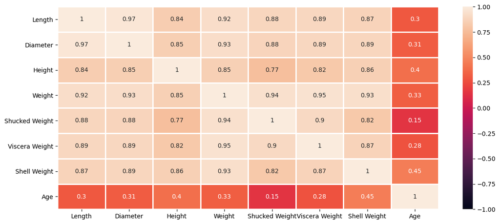

```python
plt.figure(figsize=(14,6))
corr=df.corr(method='pearson')
heatmap=sns.heatmap(corr,annot=True,vmax=1,vmin=-1,linewidths=1,linecolor='White')
plt.show()
```

[figure not shown]

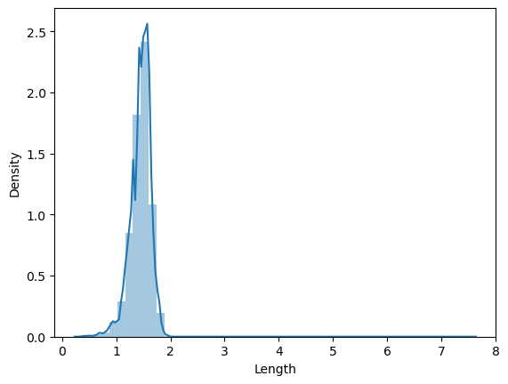

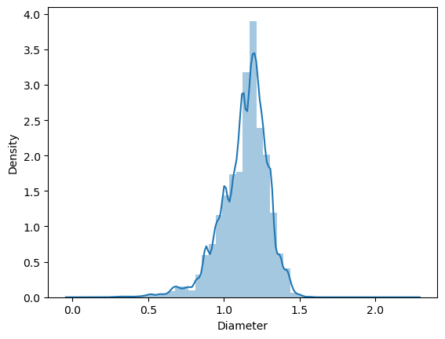

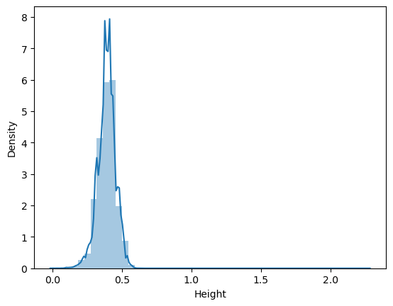

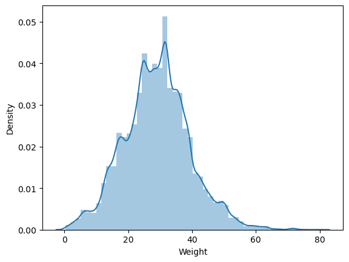

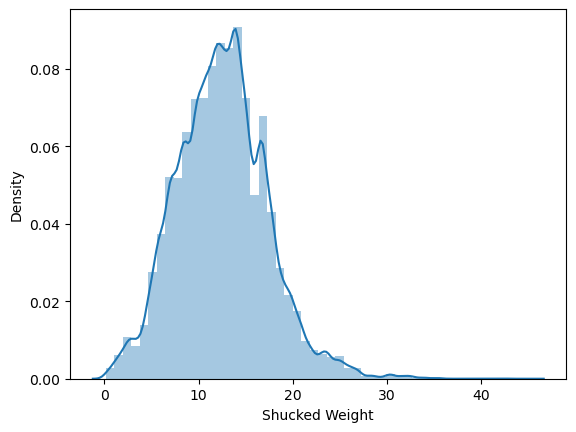

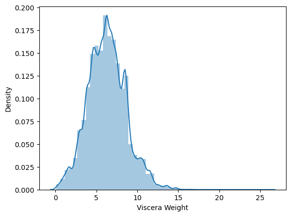

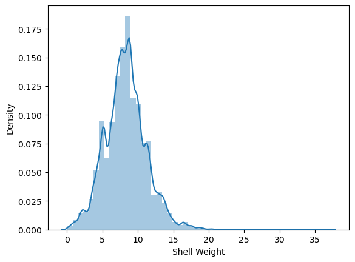

[figure not shown]

```python
for i in df.columns:
    sns.distplot(df[i])
    plt.show()
```

[figure not shown]

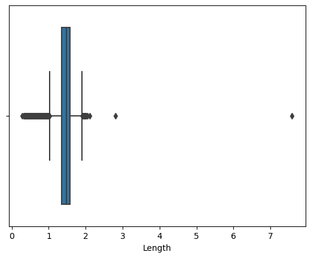

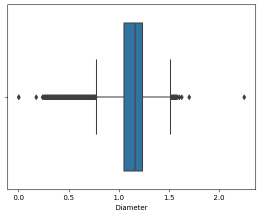

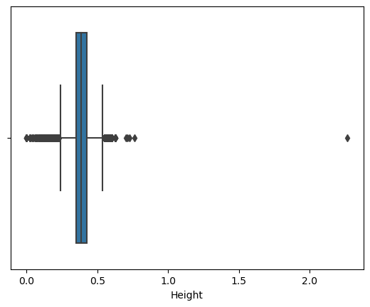

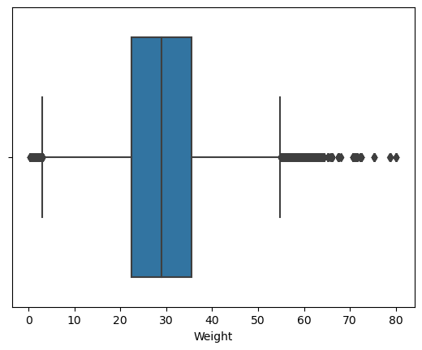

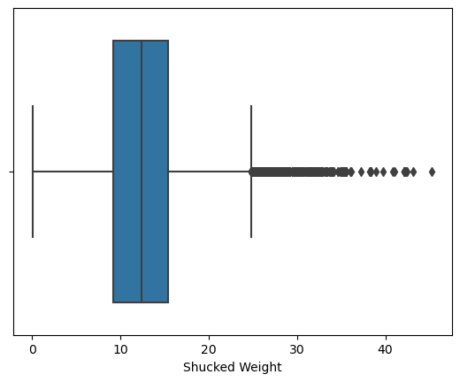

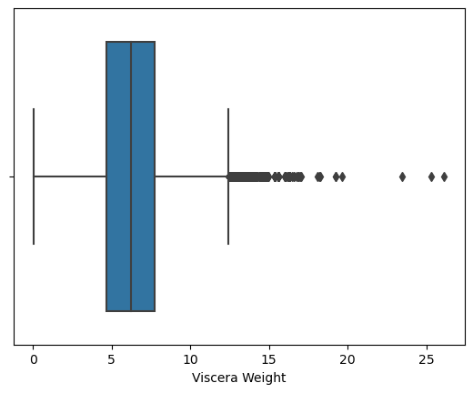

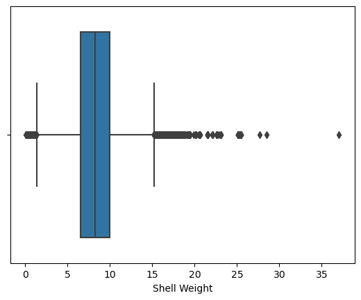

[figure not shown]

```python
for i in df.columns:
    sns.boxplot(df[i])
    plt.show()
```

[figure not shown]

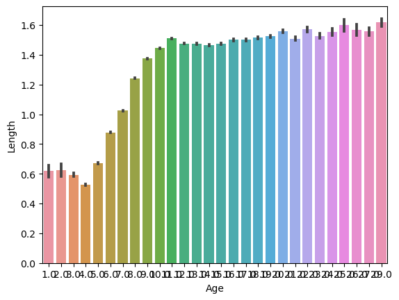

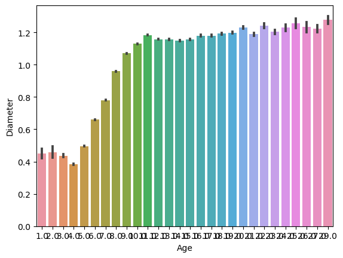

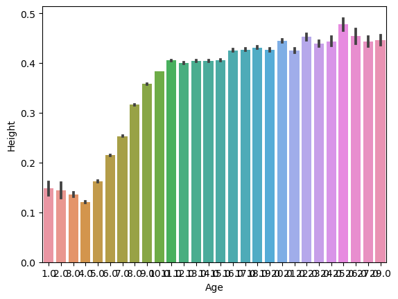

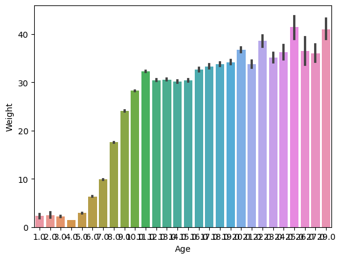

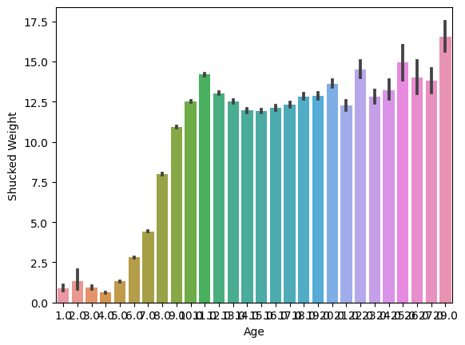

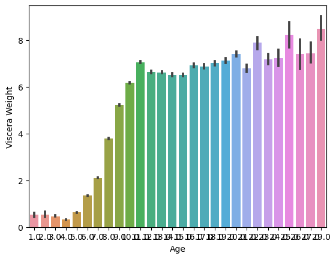

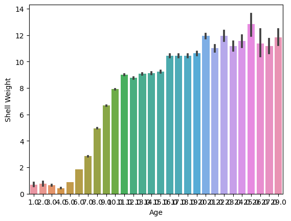

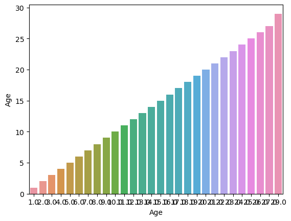

```python
for i in df.columns:
    sns.barplot(data=df,x='Age',y=i)
    plt.show()
```

```python
df.columns
```

```
Index(['Sex', 'Length', 'Diameter', 'Height', 'Weight', 'Shucked Weight',
       'Viscera Weight', 'Shell Weight', 'Age'],
      dtype='object')
```

```python
df.head()
```

[output not shown]

```python
df['Age']=df['Age'].apply(lambda x:1 if x>13 else 0)
df['Age'].unique()
```

```
array([0, 1], dtype=int64)
```

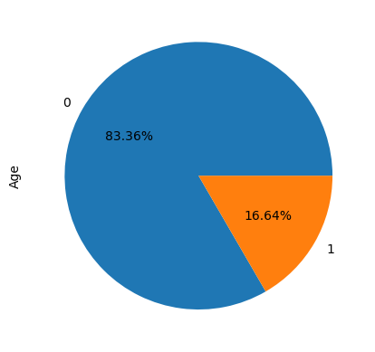

```python
df['Age'].value_counts().plot.pie(autopct="%.2f%%")
```

## AS WE CAN SEE CRABS WITH AGE LESS THAN 13 ARE MORE THAN THOSE WITH AGE GREATER THAN 13

```python
from sklearn.model_selection import train_test_split
from sklearn.neighbors import KNeighborsClassifier
from sklearn.preprocessing import StandardScaler,LabelEncoder
from sklearn.metrics import classification_report,accuracy_score
```

```python
le=LabelEncoder()
df['Sex']=le.fit_transform(df['Sex'])
```

```python
df['Sex'].unique()
```

```
array([1, 0])
```

```python
X=df.iloc[:,:-1]
y=df['Age']
```

```python
X_train,X_test,y_train,y_test=train_test_split(X,y,test_size=0.20,random_state=123)
```

```python
print(X_train.shape,y_train.shape)
print(X_test.shape,y_test.shape)
```

```
(106693, 8) (106693,)
(26674, 8) (26674,)
```

```python
se=StandardScaler()
X_train=se.fit_transform(X_train)
X_test=se.fit_transform(X_test)
```

```python
le=LabelEncoder()
df['Age']=le.fit_transform(df['Age'])
```

```python
kn=KNeighborsClassifier()
kn.fit(X_train,y_train)
```

```
KNeighborsClassifier()
```

```python
y_train_pred=kn.predict(X_train)
y_test_pred=kn.predict(X_test)
```

```python
print(accuracy_score(y_train,y_train_pred))
print(accuracy_score(y_test,y_test_pred))
```

```
0.8910237785046816
0.8535652695508735
```

```python
from sklearn.ensemble import RandomForestClassifier
from sklearn.ensemble import BaggingClassifier
```

```python
clf_rf=RandomForestClassifier(n_estimators=200,max_depth=5,criterion="entropy")
clf_rf.fit(X_train,y_train)
y_train_pred=clf_rf.predict(X_train)
y_test_pred=clf_rf.predict(X_test)
```

```python
y_train_proba=kn.predict(X_train)
y_test_proba=kn.predict(X_test)
```

```python
from sklearn.metrics import classification_report
print("train Data")
print(classification_report(y_train,y_train_pred))
print("train Data")
print(classification_report(y_test,y_test_pred))
```

[output not shown]

```python
from sklearn.metrics._plot.precision_recall_curve import precision_recall_curve
p,r,th=precision_recall_curve(y_train,y_train_proba)
```

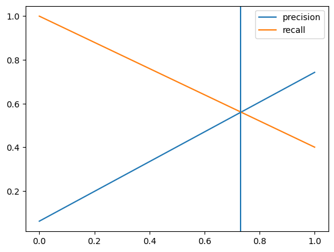

```python
sns.lineplot(x=th,y=p[:-1],label="precision")
sns.lineplot(x=th,y=r[:-1],label="recall")
plt.legend()
plt.axvline(0.73)
plt.show()
```

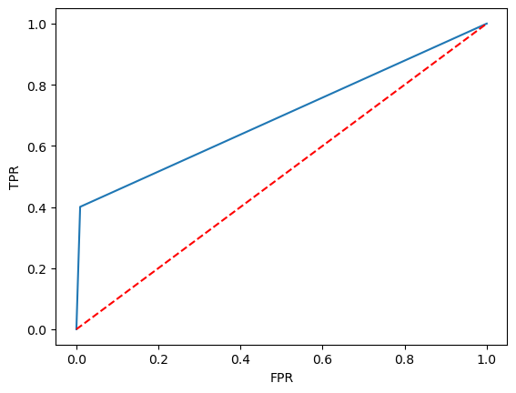

```python
from sklearn.metrics import roc_curve
fpr,tpr,th=roc_curve(y_train,y_train_proba)
sns.lineplot(x=fpr,y=tpr)
sns.lineplot(x=[0.0,1.0],y=[0.0,1.0],color="red",linestyle="--")
plt.xlabel("FPR")
plt.ylabel("TPR")
plt.show()
```

```python
from sklearn.ensemble import RandomForestClassifier
from sklearn.ensemble import AdaBoostClassifier
from sklearn.ensemble import BaggingClassifier
from sklearn.ensemble import VotingClassifier
```

```python
from sklearn.tree import plot_tree
from sklearn.tree import DecisionTreeClassifier
```

```python
dt=DecisionTreeClassifier()
dt.fit(X_train,y_train)
```

```
DecisionTreeClassifier()
```

```python
y_train_pred=dt.predict(X_train)
y_test_pred=dt.predict(X_test)
```

```python
print(classification_report(y_train,y_train_pred))
print(classification_report(y_test,y_test_pred))
```

[output not shown]

```python
dt1=DecisionTreeClassifier(max_depth=10)
dt1.fit(X_train,y_train)
```

```
DecisionTreeClassifier(max_depth=10)
```

```python
y_train_pred=dt1.predict(X_train)
y_test_pred=dt1.predict(X_test)
```

```python
print(classification_report(y_train,y_train_pred))
print(classification_report(y_test,y_test_pred))
```

[output not shown]

[figure not shown]

```python
fig,ax=plt.subplots(figsize=(10,10))
chart=plot_tree(dt1,max_depth=3,feature_names=X.columns,filled=True,fontsize=10)
```